# Loan Data from Prosper Exploration

This Dataset has been received from Propser Loans, a peer to peer lending marketplace in the United States. They have facilitated more than $14 Billion in loans to more than 880,000 people since 2005.

```python
import numpy as np
import pandas as pd
import matplotlib.pyplot as plt
import seaborn as sb
```

```python
df = pd.read_csv('prosperLoanData.csv')
```

```python
df.info()
```

```
<class 'pandas.core.frame.DataFrame'>
RangeIndex: 113937 entries, 0 to 113936
Data columns (total 81 columns):
ListingKey                             113937 non-null object
ListingNumber                          113937 non-null int64
ListingCreationDate                    113937 non-null object
CreditGrade                            28953 non-null object
Term                                   113937 non-null int64
LoanStatus                             113937 non-null object
ClosedDate                             55089 non-null object
BorrowerAPR                            113912 non-null float64
BorrowerRate                           113937 non-null float64
LenderYield                            113937 non-null float64
EstimatedEffectiveYield                84853 non-null float64
EstimatedLoss                          84853 non-null float64
EstimatedReturn                        84853 non-null float64
ProsperRating (numeric)                84853 non-null float64
ProsperRating (Alpha)                  84853 non-null object
ProsperScore                           84853 non-null float64
ListingCategory (numeric)              113937 non-null int64
BorrowerState                          108422 non-null object
Occupation                             110349 non-null object
EmploymentStatus                       111682 non-null object
EmploymentStatusDuration               106312 non-null float64
IsBorrowerHomeowner                    113937 non-null bool
CurrentlyInGroup                       113937 non-null bool
GroupKey                               13341 non-null object
DateCreditPulled                       113937 non-null object
CreditScoreRangeLower                  113346 non-null float64
CreditScoreRangeUpper                  113346 non-null float64
FirstRecordedCreditLine                113240 non-null object
CurrentCreditLines                     106333 non-null float64
OpenCreditLines                        106333 non-null float64
TotalCreditLinespast7years             113240 non-null float64
OpenRevolvingAccounts                  113937 non-null int64
OpenRevolvingMonthlyPayment            113937 non-null float64
InquiriesLast6Months                   113240 non-null float64
TotalInquiries                         112778 non-null float64
CurrentDelinquencies                   113240 non-null float64
AmountDelinquent                       106315 non-null float64
```

[output cut: 31 more lines]

```
LP_CustomerPayments                    113937 non-null float64
LP_CustomerPrincipalPayments           113937 non-null float64
LP_InterestandFees                     113937 non-null float64
LP_ServiceFees                         113937 non-null float64
LP_CollectionFees                      113937 non-null float64
LP_GrossPrincipalLoss                  113937 non-null float64
LP_NetPrincipalLoss                    113937 non-null float64
LP_NonPrincipalRecoverypayments        113937 non-null float64
PercentFunded                          113937 non-null float64
Recommendations                        113937 non-null int64
InvestmentFromFriendsCount             113937 non-null int64
InvestmentFromFriendsAmount            113937 non-null float64
Investors                              113937 non-null int64
dtypes: bool(3), float64(50), int64(11), object(17)
memory usage: 68.1+ MB
```

```python
df.describe()
```

|  | ListingNumber | Term | BorrowerAPR | BorrowerRate | LenderYield | EstimatedEffectiveYield | EstimatedLoss | EstimatedReturn | ProsperRating (numeric) | ProsperScore | ... | LP_ServiceFees | LP_CollectionFees | LP_GrossPrincipalLoss | LP_NetPrincipalLoss | LP_NonPrincipalRecoverypayments | PercentFunded | Recommendations | InvestmentFromFriendsCount | InvestmentFromFriendsAmount | Investors |
| --- | --- | --- | --- | --- | --- | --- | --- | --- | --- | --- | --- | --- | --- | --- | --- | --- | --- | --- | --- | --- | --- |
| count | 1.139370e+05 | 113937.000000 | 113912.000000 | 113937.000000 | 113937.000000 | 84853.000000 | 84853.000000 | 84853.000000 | 84853.000000 | 84853.000000 | ... | 113937.000000 | 113937.000000 | 113937.000000 | 113937.000000 | 113937.000000 | 113937.000000 | 113937.000000 | 113937.000000 | 113937.000000 | 113937.000000 |
| mean | 6.278857e+05 | 40.830248 | 0.218828 | 0.192764 | 0.182701 | 0.168661 | 0.080306 | 0.096068 | 4.072243 | 5.950067 | ... | -54.725641 | -14.242698 | 700.446342 | 681.420499 | 25.142686 | 0.998584 | 0.048027 | 0.023460 | 16.550751 | 80.475228 |
| std | 3.280762e+05 | 10.436212 | 0.080364 | 0.074818 | 0.074516 | 0.068467 | 0.046764 | 0.030403 | 1.673227 | 2.376501 | ... | 60.675425 | 109.232758 | 2388.513831 | 2357.167068 | 275.657937 | 0.017919 | 0.332353 | 0.232412 | 294.545422 | 103.239020 |
| min | 4.000000e+00 | 12.000000 | 0.006530 | 0.000000 | -0.010000 | -0.182700 | 0.004900 | -0.182700 | 1.000000 | 1.000000 | ... | -664.870000 | -9274.750000 | -94.200000 | -954.550000 | 0.000000 | 0.700000 | 0.000000 | 0.000000 | 0.000000 | 1.000000 |
| 25% | 4.009190e+05 | 36.000000 | 0.156290 | 0.134000 | 0.124200 | 0.115670 | 0.042400 | 0.074080 | 3.000000 | 4.000000 | ... | -73.180000 | 0.000000 | 0.000000 | 0.000000 | 0.000000 | 1.000000 | 0.000000 | 0.000000 | 0.000000 | 2.000000 |
| 50% | 6.005540e+05 | 36.000000 | 0.209760 | 0.184000 | 0.173000 | 0.161500 | 0.072400 | 0.091700 | 4.000000 | 6.000000 | ... | -34.440000 | 0.000000 | 0.000000 | 0.000000 | 0.000000 | 1.000000 | 0.000000 | 0.000000 | 0.000000 | 44.000000 |
| 75% | 8.926340e+05 | 36.000000 | 0.283810 | 0.250000 | 0.240000 | 0.224300 | 0.112000 | 0.116600 | 5.000000 | 8.000000 | ... | -13.920000 | 0.000000 | 0.000000 | 0.000000 | 0.000000 | 1.000000 | 0.000000 | 0.000000 | 0.000000 | 115.000000 |
| max | 1.255725e+06 | 60.000000 | 0.512290 | 0.497500 | 0.492500 | 0.319900 | 0.366000 | 0.283700 | 7.000000 | 11.000000 | ... | 32.060000 | 0.000000 | 25000.000000 | 25000.000000 | 21117.900000 | 1.012500 | 39.000000 | 33.000000 | 25000.000000 | 1189.000000 |

8 rows × 61 columns

This Dataset contains 113,937 loans with 81 different variables on each loan ranging from loan amount to borrower rate and income. The data is going to be explored by using different plots to create insights that could be of importance to the reader.

I'm most interested in figuring out how the different income ranges influence other factors such as the loan amount and the borrower rate. I am also interested in seeing the relationship between the Prosper Rating and other factors

## Univariate Exploration

```python
df["DebtToIncomeRatio"].isnull().sum()
```

```
8554
```

```python
df["DebtToIncomeRatio"].fillna(df["MonthlyLoanPayment"] / (df["StatedMonthlyIncome"] + 1), inplace = True)
```

In the cell above I have filled in all missing values in the debt to income ratio column by dividing the monthly loan payment by the stated monthly income for each loan.

```python
df2 = df[['ListingCreationDate', 'LoanStatus', 'CreditGrade','ProsperRating (numeric)', 'ProsperRating (Alpha)', 'ProsperScore', 'ListingCategory (numeric)', 'IsBorrowerHomeowner', 'CreditScoreRangeUpper', 'IncomeRange', 'LoanOriginalAmount',  'BorrowerRate', 'BorrowerAPR', 'DebtToIncomeRatio']]
```

I have extracted the columns I believe would be the most significant in carrying out the proposed plot analyses

```python
df2.head(5)
```

|  | ListingCreationDate | LoanStatus | CreditGrade | ProsperRating (numeric) | ProsperRating (Alpha) | ProsperScore | ListingCategory (numeric) | IsBorrowerHomeowner | CreditScoreRangeUpper | IncomeRange | LoanOriginalAmount | BorrowerRate | BorrowerAPR | DebtToIncomeRatio |
| --- | --- | --- | --- | --- | --- | --- | --- | --- | --- | --- | --- | --- | --- | --- |
| 0 | 2007-08-26 19:09:29.263000000 | Completed | C | NaN | NaN | NaN | 0 | True | 659.0 | $25,000-49,999 | 9425 | 0.1580 | 0.16516 | 0.17 |
| 1 | 2014-02-27 08:28:07.900000000 | Current | NaN | 6.0 | A | 7.0 | 2 | False | 699.0 | $50,000-74,999 | 10000 | 0.0920 | 0.12016 | 0.18 |
| 2 | 2007-01-05 15:00:47.090000000 | Completed | HR | NaN | NaN | NaN | 0 | False | 499.0 | Not displayed | 3001 | 0.2750 | 0.28269 | 0.06 |
| 3 | 2012-10-22 11:02:35.010000000 | Current | NaN | 6.0 | A | 9.0 | 16 | True | 819.0 | $25,000-49,999 | 10000 | 0.0974 | 0.12528 | 0.15 |
| 4 | 2013-09-14 18:38:39.097000000 | Current | NaN | 3.0 | D | 4.0 | 2 | True | 699.0 | $100,000+ | 15000 | 0.2085 | 0.24614 | 0.26 |

I'll now look at the number of individuals in each income range

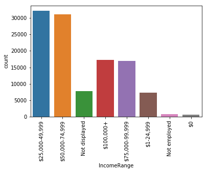

```python
sb.countplot(data = df2, x = 'IncomeRange');
plt.xticks(rotation=90);
```

A high percentage of people are within the income ranges of 25,000 and 74,999 dollars which accurately depicts the reality of most individuals

Next I want to look at the loan status data to see how many loans proser currently handles the status of those that aren't current anymore

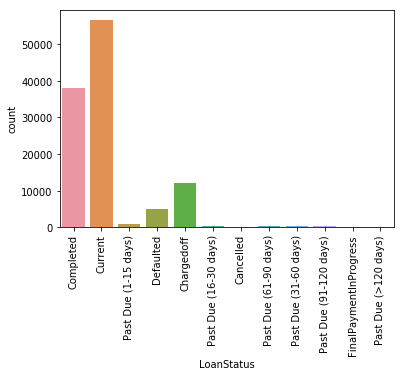

```python
# Visualize loan status values
sb.countplot(data = df2, x = 'LoanStatus');
plt.xticks(rotation=90);
```

I'll now look at the distribution of the borrower rate and borrower apr, I'll use the describe function to get the minimum and maximum values in order to create suitable bins for the histograms

```python
df2['BorrowerRate'].describe(), df2['BorrowerAPR'].describe()
```

```
(count    113937.000000
 mean          0.192764
 std           0.074818
 min           0.000000
 25%           0.134000
 50%           0.184000
 75%           0.250000
 max           0.497500
 Name: BorrowerRate, dtype: float64, count    113912.000000
 mean          0.218828
 std           0.080364
 min           0.006530
 25%           0.156290
 50%           0.209760
 75%           0.283810
 max           0.512290
 Name: BorrowerAPR, dtype: float64)
```

```python
df2.BorrowerAPR.isnull().sum()
```

```
25
```

```python
df2.dropna(subset=['BorrowerAPR'], inplace=True)
```

```python
df2.BorrowerAPR.isnull().sum()
```

```
0
```

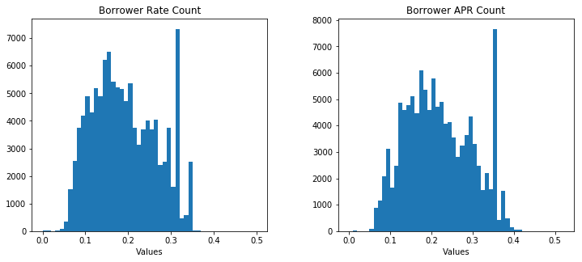

```python
# Creating bin edges for both plots and putting them side by side in subplots
plt.figure(figsize=(12,5))
plt.subplot(1, 2, 1)
bin_edges = np.arange(0, df2.BorrowerRate.max()+0.01, 0.01);
plt.hist(data = df2, x = 'BorrowerRate', bins = bin_edges);
plt.title('Borrower Rate Count')
plt.xlabel('Values')

plt.subplot(1, 2, 2)
bin_edges = np.arange(0, df2.BorrowerAPR.max()+0.01, 0.01);
plt.hist(data = df2, x = 'BorrowerAPR', bins = bin_edges);
plt.xlabel('Values')

plt.subplots_adjust(bottom=0.15, wspace=0.3)
plt.title('Borrower APR Count');
```

Both plots have very similar distributions which is accurate because the APR is the borrower rate with some additional fees from prosper. Both the rate and APR have a peak between 0.3 and 0.4

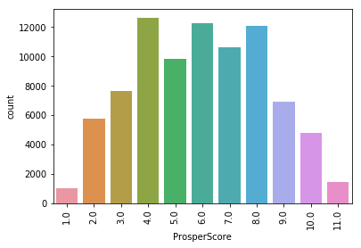

```python
sb.countplot(data = df2, x = 'ProsperScore');
plt.xticks(rotation=90);
```

This shows an even distribution with most people being between the scores of 4 and 8 and only a few people having perfect scores or the worst score

Next I'll look at the distribution of the listing categories to see the most popular reasons for taking out a loan

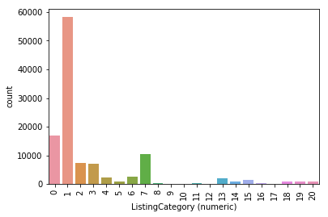

```python
sb.countplot(data = df2, x = 'ListingCategory (numeric)');
plt.xticks(rotation=90);
```

The most popular reason for taking out a loan is for debt consolidation with over 50000 people on the listing, this is followed by other, which does not provide enough information.

Next I am going to look at the distribution of the debt to income and ratio

```python
df2['DebtToIncomeRatio'].describe()
```

```
count    113912.000000
mean          3.022987
std          33.540017
min           0.000000
25%           0.130000
50%           0.210000
75%           0.310000
max        1130.900000
Name: DebtToIncomeRatio, dtype: float64
```

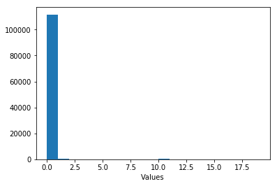

```python
bin_edges = np.arange(0, 20, 1);
plt.hist(data = df2, x = 'DebtToIncomeRatio', bins = bin_edges);
plt.xlabel('Values')
```

The plot above does not provide any useful information, there seems to be a huge outlier so it would be better to zoom in to the data to provide a better picture

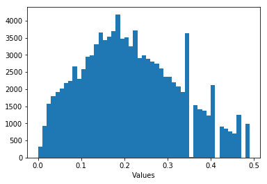

```python
bin_edges = np.arange(0, 0.5, 0.01);
plt.hist(data = df2, x = 'DebtToIncomeRatio', bins = bin_edges);
plt.xlabel('Values');
```

The plot above displays a better story because most of the debt to income ratio values fall in between 0 and 0.5, so an outlier of 10 was probably an error.

The Debt to Income Ratio column had a lot of missing values, I changed the data by filling in those values by dividing the monthly payment column by the stated monthly income column both of which did not have missing values, because this is how to calculate the debt to income ratio.

## Bivariate Exploration

```python
df2.describe()
```

|  | ProsperRating (numeric) | ProsperScore | ListingCategory (numeric) | CreditScoreRangeUpper | LoanOriginalAmount | BorrowerRate | BorrowerAPR | DebtToIncomeRatio |
| --- | --- | --- | --- | --- | --- | --- | --- | --- |
| count | 84853.000000 | 84853.000000 | 113912.000000 | 113346.000000 | 113912.000000 | 113912.000000 | 113912.000000 | 113912.000000 |
| mean | 4.072243 | 5.950067 | 2.774817 | 704.567731 | 8338.015661 | 0.192786 | 0.218828 | 3.022987 |
| std | 1.673227 | 2.376501 | 3.997024 | 66.458275 | 6245.940592 | 0.074809 | 0.080364 | 33.540017 |
| min | 1.000000 | 1.000000 | 0.000000 | 19.000000 | 1000.000000 | 0.000000 | 0.006530 | 0.000000 |
| 25% | 3.000000 | 4.000000 | 1.000000 | 679.000000 | 4000.000000 | 0.134000 | 0.156290 | 0.130000 |
| 50% | 4.000000 | 6.000000 | 1.000000 | 699.000000 | 6500.000000 | 0.184000 | 0.209760 | 0.210000 |
| 75% | 5.000000 | 8.000000 | 3.000000 | 739.000000 | 12000.000000 | 0.250000 | 0.283810 | 0.310000 |
| max | 7.000000 | 11.000000 | 20.000000 | 899.000000 | 35000.000000 | 0.497500 | 0.512290 | 1130.900000 |

To start off with, I want to put the income range values into categoriies

```python
df2.IncomeRange.value_counts()
```

```
$25,000-49,999    32192
$50,000-74,999    31050
$100,000+         17337
$75,000-99,999    16916
Not displayed      7716
$1-24,999          7274
Not employed        806
$0                  621
Name: IncomeRange, dtype: int64
```

```python
income_ranges = ['Not employed', '$0', '$1-24,999', '$25,000-49,999', '$50,000-74,999', '$75,000-99,999', '$100,000+', 'Not displayed']
incomerange = pd.api.types.CategoricalDtype(ordered = True, categories = income_ranges)
df2['IncomeRange'] = df2['IncomeRange'].astype(incomerange)
```

Next I want to plot the relationship between the original loan amount and each income range category

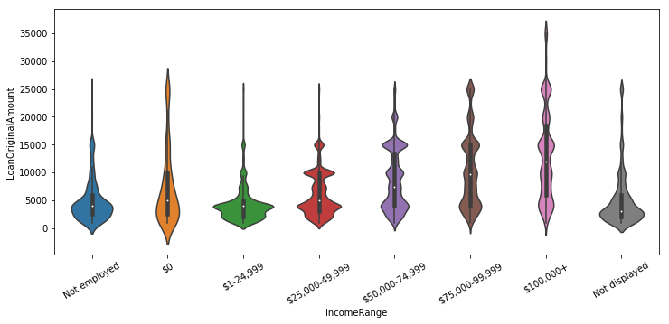

```python
plt.figure(figsize=(12,5))
sb.violinplot(data = df2, x = 'IncomeRange', y = 'LoanOriginalAmount');
plt.xticks(rotation=30);
```

Next I have noticed that the CreditGrade and ProsperRating Columns have the same information, Credit grade has pre 2009 information and prosper rating has post 2009 information so I am going to merge the information into one columns

```python
df2['ProsperRating (Alpha)'].isnull().sum()
```

```
29059
```

```python
df2['ProsperRating (Alpha)'].value_counts()
```

```
C     18345
B     15581
A     14551
D     14274
E      9795
HR     6935
AA     5372
Name: ProsperRating (Alpha), dtype: int64
```

```python
df2['CreditGrade'].value_counts()
```

```
C     5646
D     5152
B     4387
HR    3506
AA    3495
A     3314
E     3288
NC     140
Name: CreditGrade, dtype: int64
```

```python
df2['ProsperRating (Alpha)'].fillna(df['CreditGrade'], inplace = True)
```

```python
df2['ProsperRating (Alpha)'].isnull().sum()
```

```
131
```

```python
df2['ProsperRating (Alpha)'].value_counts()
```

```
C     23991
B     19968
D     19426
A     17865
E     13083
HR    10441
AA     8867
NC      140
Name: ProsperRating (Alpha), dtype: int64
```

```python
df2['ProsperRating (numeric)'].value_counts()
```

```
4.0    18345
5.0    15581
6.0    14551
3.0    14274
2.0     9795
1.0     6935
7.0     5372
Name: ProsperRating (numeric), dtype: int64
```

Next I am going to replace the alphabetic ratings with numeric ratings based on the column descriptions provided. Then I will drop the older proper rating numeric column because it contains the same information but with a lot more null values

```python
df2 = df2.replace({'ProsperRating (Alpha)': {'HR': 1, 'E': 2, 'D': 3, 'C': 4, 'B': 5, 'A': 6, 'AA': 7, }})
```

```python
df2['ProsperRating (Alpha)'].value_counts()
```

```
4     23991
5     19968
3     19426
6     17865
2     13083
1     10441
7      8867
NC      140
Name: ProsperRating (Alpha), dtype: int64
```

```python
df2.info()
```

```
<class 'pandas.core.frame.DataFrame'>
Int64Index: 113912 entries, 0 to 113936
Data columns (total 14 columns):
ListingCreationDate          113912 non-null object
LoanStatus                   113912 non-null object
CreditGrade                  28928 non-null object
ProsperRating (numeric)      84853 non-null float64
ProsperRating (Alpha)        113781 non-null object
ProsperScore                 84853 non-null float64
ListingCategory (numeric)    113912 non-null int64
IsBorrowerHomeowner          113912 non-null bool
CreditScoreRangeUpper        113346 non-null float64
IncomeRange                  113912 non-null category
LoanOriginalAmount           113912 non-null int64
BorrowerRate                 113912 non-null float64
BorrowerAPR                  113912 non-null float64
DebtToIncomeRatio            113912 non-null float64
dtypes: bool(1), category(1), float64(6), int64(2), object(4)
memory usage: 11.5+ MB
```

```python
df2.dropna(subset=['ProsperRating (Alpha)'], inplace=True)
```

```python
# They dont have income ranges or listing categories, creditscore is just 19
df2[df2['ProsperRating (Alpha)'] == 'NC']
```

|  | ListingCreationDate | LoanStatus | CreditGrade | ProsperRating (numeric) | ProsperRating (Alpha) | ProsperScore | ListingCategory (numeric) | IsBorrowerHomeowner | CreditScoreRangeUpper | IncomeRange | LoanOriginalAmount | BorrowerRate | BorrowerAPR | DebtToIncomeRatio |
| --- | --- | --- | --- | --- | --- | --- | --- | --- | --- | --- | --- | --- | --- | --- |
| 794 | 2007-02-11 13:40:55.490000000 | Completed | NC | NaN | NC | NaN | 0 | False | 19.0 | Not displayed | 4000 | 0.2900 | 0.29776 | 1.437770 |
| 912 | 2006-11-14 08:23:08.430000000 | Defaulted | NC | NaN | NC | NaN | 0 | False | 19.0 | Not displayed | 1500 | 0.2600 | 0.27276 | 0.030000 |
| 1685 | 2007-02-06 15:50:46.723000000 | Chargedoff | NC | NaN | NC | NaN | 0 | False | 19.0 | Not displayed | 1000 | 0.1625 | 0.18065 | 0.022036 |
| 4290 | 2006-04-23 14:19:41.030000000 | Chargedoff | NC | NaN | NC | NaN | 0 | False | 19.0 | Not displayed | 4000 | 0.2375 | 0.24502 | 0.103680 |
| 4371 | 2006-08-14 11:45:59.710000000 | Defaulted | NC | NaN | NC | NaN | 0 | False | 19.0 | Not displayed | 1500 | 0.2325 | 0.24505 | 58.260000 |
| 4430 | 2006-09-25 07:37:29.397000000 | Defaulted | NC | NaN | NC | NaN | 0 | False | 19.0 | Not displayed | 1000 | 0.1450 | 0.16296 | 0.205288 |
| 4672 | 2007-01-30 18:37:09.950000000 | Chargedoff | NC | NaN | NC | NaN | 0 | False | 19.0 | Not displayed | 1200 | 0.1930 | 0.20836 | 0.020000 |
| 5684 | 2006-12-18 16:19:43.230000000 | Completed | NC | NaN | NC | NaN | 0 | False | 19.0 | Not displayed | 2550 | 0.2300 | 0.23748 | 0.090000 |
| 6877 | 2007-02-05 06:44:11.043000000 | Chargedoff | NC | NaN | NC | NaN | 0 | False | 19.0 | Not displayed | 1000 | 0.0700 | 0.08718 | 0.013857 |
| 7739 | 2006-10-05 21:23:10.147000000 | Chargedoff | NC | NaN | NC | NaN | 0 | False | 19.0 | Not displayed | 2500 | 0.2900 | 0.29776 | 0.070000 |
| 9048 | 2006-12-12 14:37:31.763000000 | Defaulted | NC | NaN | NC | NaN | 0 | False | 19.0 | Not displayed | 1000 | 0.2900 | 0.30962 | 0.010000 |
| 9473 | 2006-09-29 13:50:00.277000000 | Chargedoff | NC | NaN | NC | NaN | 0 | False | 19.0 | Not displayed | 2550 | 0.2500 | 0.25757 | 0.050000 |
| 9778 | 2006-03-22 17:07:20.597000000 | Defaulted | NC | NaN | NC | NaN | 0 | False | NaN | Not displayed | 2800 | 0.3295 | 0.33745 | 0.351550 |
| 13395 | 2006-04-29 18:34:51.497000000 | Defaulted | NC | NaN | NC | NaN | 0 | True | 19.0 | Not displayed | 2550 | 0.2375 | 0.24502 | 0.023930 |
| 13525 | 2006-11-02 10:26:43.313000000 | Chargedoff | NC | NaN | NC | NaN | 0 | False | 19.0 | Not displayed | 3000 | 0.2000 | 0.20735 | 0.028604 |
| 13686 | 2006-11-20 04:39:56.240000000 | Completed | NC | NaN | NC | NaN | 0 | False | 19.0 | Not displayed | 1000 | 0.1700 | 0.18824 | 0.017382 |
| 13938 | 2006-11-08 16:45:39.990000000 | Defaulted | NC | NaN | NC | NaN | 0 | False | 19.0 | Not displayed | 1000 | 0.1700 | 0.18824 | 0.020000 |
| 14338 | 2006-11-14 13:50:23.173000000 | Chargedoff | NC | NaN | NC | NaN | 0 | False | 19.0 | Not displayed | 1200 | 0.1700 | 0.18515 | 0.039453 |
| 14725 | 2006-08-15 12:49:27.613000000 | Chargedoff | NC | NaN | NC | NaN | 0 | False | 19.0 | Not displayed | 1600 | 0.1700 | 0.18132 | 0.130000 |
| 15093 | 2006-08-30 19:02:23.163000000 | Defaulted | NC | NaN | NC | NaN | 0 | False | 19.0 | Not displayed | 2000 | 0.2900 | 0.29972 | 0.140000 |
| 15137 | 2006-07-05 10:45:44.777000000 | Chargedoff | NC | NaN | NC | NaN | 0 | False | 19.0 | Not displayed | 3000 | 0.2500 | 0.25757 | 0.079467 |
| 18167 | 2006-03-20 12:29:11.053000000 | Defaulted | NC | NaN | NC | NaN | 0 | False | NaN | Not displayed | 2500 | 0.3000 | 0.30781 | 0.031840 |
| 18774 | 2006-09-25 09:08:42.530000000 | Defaulted | NC | NaN | NC | NaN | 0 | False | 19.0 | Not displayed | 2500 | 0.2800 | 0.28771 | 0.040000 |
| 18836 | 2007-01-02 01:18:30.630000000 | Defaulted | NC | NaN | NC | NaN | 0 | False | 19.0 | Not displayed | 1200 | 0.2900 | 0.30630 | 0.024166 |
| 19737 | 2006-09-20 13:38:28.487000000 | Completed | NC | NaN | NC | NaN | 0 | False | 19.0 | Not displayed | 1300 | 0.2900 | 0.30503 | 0.036296 |
| 20736 | 2006-12-06 15:48:00.640000000 | Completed | NC | NaN | NC | NaN | 0 | False | 19.0 | Not displayed | 2000 | 0.2900 | 0.29972 | 0.070000 |
| 21047 | 2006-11-23 15:00:00.923000000 | Defaulted | NC | NaN | NC | NaN | 0 | False | 19.0 | Not displayed | 1000 | 0.0900 | 0.10739 | 0.020000 |
| 21381 | 2006-03-18 19:57:36.613000000 | Completed | NC | NaN | NC | NaN | 0 | False | NaN | Not displayed | 1800 | 0.1405 | 0.15037 | 0.033580 |
| 21397 | 2007-01-03 12:32:38.743000000 | Completed | NC | NaN | NC | NaN | 0 | False | 19.0 | Not displayed | 3800 | 0.2400 | 0.24753 | 0.020000 |
| 22399 | 2006-07-12 18:02:10.357000000 | Completed | NC | NaN | NC | NaN | 0 | False | 19.0 | Not displayed | 3001 | 0.1995 | 0.20684 | 0.066830 |
| ... | ... | ... | ... | ... | ... | ... | ... | ... | ... | ... | ... | ... | ... | ... |
| 97389 | 2006-03-16 07:19:13.180000000 | Defaulted | NC | NaN | NC | NaN | 0 | False | NaN | Not displayed | 1000 | 0.1575 | 0.17560 | 0.006470 |
| 97961 | 2006-09-17 15:33:28.493000000 | Defaulted | NC | NaN | NC | NaN | 0 | False | 19.0 | Not displayed | 4000 | 0.2900 | 0.29776 | 0.040219 |
| 99180 | 2006-05-18 15:21:07.933000000 | Defaulted | NC | NaN | NC | NaN | 0 | False | 19.0 | Not displayed | 1500 | 0.2075 | 0.21986 | 0.070312 |
| 99799 | 2006-05-17 05:06:46.843000000 | Chargedoff | NC | NaN | NC | NaN | 0 | False | 19.0 | Not displayed | 1000 | 0.2075 | 0.22615 | 0.020000 |
| 99826 | 2007-01-11 15:09:52.103000000 | Completed | NC | NaN | NC | NaN | 0 | False | 19.0 | Not displayed | 1000 | 0.1500 | 0.16802 | 0.020000 |
| 100081 | 2007-01-21 14:15:25.120000000 | Completed | NC | NaN | NC | NaN | 0 | False | 19.0 | Not displayed | 5000 | 0.2150 | 0.22241 | 0.032508 |
| 100136 | 2006-02-11 14:35:58.890000000 | Defaulted | NC | NaN | NC | NaN | 0 | False | NaN | Not displayed | 3000 | 0.1625 | 0.16968 | 105.840000 |
| 100388 | 2006-10-25 15:17:50.577000000 | Chargedoff | NC | NaN | NC | NaN | 0 | False | 19.0 | Not displayed | 2125 | 0.1700 | 0.17850 | 0.058344 |
| 100942 | 2006-10-05 15:13:08.517000000 | Chargedoff | NC | NaN | NC | NaN | 0 | False | 19.0 | Not displayed | 3500 | 0.1500 | 0.15713 | 0.060000 |
| 100943 | 2006-11-30 16:45:46.153000000 | Chargedoff | NC | NaN | NC | NaN | 0 | False | 19.0 | Not displayed | 2550 | 0.2525 | 0.26008 | 0.063542 |
| 100973 | 2006-06-05 07:36:12.540000000 | Defaulted | NC | NaN | NC | NaN | 0 | False | 19.0 | Not displayed | 3001 | 0.2700 | 0.27767 | 0.050000 |
| 101018 | 2006-12-27 13:22:24.133000000 | Defaulted | NC | NaN | NC | NaN | 0 | False | 19.0 | Not displayed | 1000 | 0.2900 | 0.30962 | 0.040000 |
| 101859 | 2006-07-31 09:34:52.640000000 | Defaulted | NC | NaN | NC | NaN | 0 | False | 19.0 | Not displayed | 3001 | 0.2481 | 0.25566 | 0.047589 |
| 102032 | 2006-07-01 16:43:29.480000000 | Chargedoff | NC | NaN | NC | NaN | 0 | False | 19.0 | Not displayed | 1250 | 0.2500 | 0.26526 | 0.020000 |
| 102090 | 2006-07-31 14:07:30.360000000 | Defaulted | NC | NaN | NC | NaN | 0 | False | 19.0 | Not displayed | 3600 | 0.1150 | 0.12198 | 0.000000 |
| 102229 | 2007-01-14 18:20:42.747000000 | Chargedoff | NC | NaN | NC | NaN | 0 | False | 19.0 | Not displayed | 2550 | 0.2900 | 0.29776 | 0.089410 |
| 102840 | 2006-06-06 05:57:28.367000000 | Chargedoff | NC | NaN | NC | NaN | 0 | False | 19.0 | Not displayed | 2550 | 0.2200 | 0.22744 | 0.029208 |
| 103001 | 2006-09-26 06:55:02.710000000 | Defaulted | NC | NaN | NC | NaN | 0 | False | 19.0 | Not displayed | 3031 | 0.2700 | 0.27767 | 13.257858 |
| 103065 | 2006-10-19 18:05:43.267000000 | Defaulted | NC | NaN | NC | NaN | 0 | False | 19.0 | Not displayed | 1000 | 0.2300 | 0.24891 | 0.023212 |
| 103726 | 2007-01-14 19:37:29.733000000 | Defaulted | NC | NaN | NC | NaN | 0 | False | 19.0 | Not displayed | 1000 | 0.2350 | 0.25397 | 0.023368 |
| 105032 | 2006-07-25 02:21:31.797000000 | Defaulted | NC | NaN | NC | NaN | 0 | False | 19.0 | Not displayed | 3300 | 0.2900 | 0.29776 | 0.140000 |
| 106897 | 2006-12-11 22:04:10.833000000 | Defaulted | NC | NaN | NC | NaN | 0 | False | 19.0 | Not displayed | 2550 | 0.2900 | 0.29776 | 0.040000 |
| 108762 | 2006-07-06 15:05:40.293000000 | Defaulted | NC | NaN | NC | NaN | 0 | False | 19.0 | Not displayed | 1000 | 0.2400 | 0.25903 | 0.040000 |
| 109060 | 2007-01-10 09:29:46.457000000 | Defaulted | NC | NaN | NC | NaN | 0 | False | 19.0 | Not displayed | 1000 | 0.2500 | 0.26914 | 0.079361 |
| 109468 | 2007-02-10 13:23:56.823000000 | Completed | NC | NaN | NC | NaN | 0 | False | 19.0 | Not displayed | 2550 | 0.1200 | 0.12700 | 78.184639 |
| 109522 | 2006-11-13 06:36:16.067000000 | Chargedoff | NC | NaN | NC | NaN | 0 | False | 19.0 | Not displayed | 1200 | 0.2000 | 0.21543 | 0.026092 |
| 109855 | 2007-01-17 13:07:35.540000000 | Completed | NC | NaN | NC | NaN | 0 | False | 19.0 | Not displayed | 3001 | 0.2190 | 0.22643 | 0.060000 |
| 110290 | 2007-02-10 21:22:12.553000000 | Chargedoff | NC | NaN | NC | NaN | 0 | False | 19.0 | Not displayed | 1000 | 0.1594 | 0.17752 | 0.010000 |
| 111624 | 2007-01-07 20:33:39.027000000 | Defaulted | NC | NaN | NC | NaN | 0 | False | 19.0 | Not displayed | 3002 | 0.2900 | 0.29776 | 0.053891 |
| 113848 | 2007-02-07 15:04:40.563000000 | Completed | NC | NaN | NC | NaN | 0 | False | 19.0 | Not displayed | 1000 | 0.2875 | 0.30709 | 0.000000 |

140 rows × 14 columns

```python
# Drop rows with NC
df2 = df2[df2['ProsperRating (Alpha)'] != 'NC']
```

```python
df2['ProsperRating (Alpha)'].value_counts()
```

```
4    23991
5    19968
3    19426
6    17865
2    13083
1    10441
7     8867
Name: ProsperRating (Alpha), dtype: int64
```

```python
df2.head(1)
```

|  | ListingCreationDate | LoanStatus | CreditGrade | ProsperRating (numeric) | ProsperRating (Alpha) | ProsperScore | ListingCategory (numeric) | IsBorrowerHomeowner | CreditScoreRangeUpper | IncomeRange | LoanOriginalAmount | BorrowerRate | BorrowerAPR | DebtToIncomeRatio |
| --- | --- | --- | --- | --- | --- | --- | --- | --- | --- | --- | --- | --- | --- | --- |
| 0 | 2007-08-26 19:09:29.263000000 | Completed | C | NaN | 4 | NaN | 0 | True | 659.0 | $25,000-49,999 | 9425 | 0.158 | 0.16516 | 0.17 |

```python
df2['ProsperRating (Alpha)'].isnull().sum()
```

```
0
```

```python
df2.dropna(subset=['ProsperRating (Alpha)'], inplace=True)
```

```python
df2['ProsperRating (Alpha)'] = df2['ProsperRating (Alpha)'].astype(int)
```

```python
df2.drop(['CreditGrade', 'ProsperRating (numeric)'], axis = 1, inplace = True)
```

```python
df2 = df2.rename(columns={'ProsperRating (Alpha)': 'ProsperRating'})
```

```python
df2.head(1)
```

|  | ListingCreationDate | LoanStatus | ProsperRating | ProsperScore | ListingCategory (numeric) | IsBorrowerHomeowner | CreditScoreRangeUpper | IncomeRange | LoanOriginalAmount | BorrowerRate | BorrowerAPR | DebtToIncomeRatio |
| --- | --- | --- | --- | --- | --- | --- | --- | --- | --- | --- | --- | --- |
| 0 | 2007-08-26 19:09:29.263000000 | Completed | 4 | NaN | 0 | True | 659.0 | $25,000-49,999 | 9425 | 0.158 | 0.16516 | 0.17 |

Next I am going to change the listing creation date column to datetime datatype and extract the year into a new column for further analysis of the dataset

```python
df2['ListingCreationDate'] = pd.to_datetime(df2['ListingCreationDate'])
```

```python
df2.info()
```

```
<class 'pandas.core.frame.DataFrame'>
Int64Index: 113641 entries, 0 to 113936
Data columns (total 12 columns):
ListingCreationDate          113641 non-null datetime64[ns]
LoanStatus                   113641 non-null object
ProsperRating                113641 non-null int64
ProsperScore                 84853 non-null float64
ListingCategory (numeric)    113641 non-null int64
IsBorrowerHomeowner          113641 non-null bool
CreditScoreRangeUpper        113085 non-null float64
IncomeRange                  113641 non-null category
LoanOriginalAmount           113641 non-null int64
BorrowerRate                 113641 non-null float64
BorrowerAPR                  113641 non-null float64
DebtToIncomeRatio            113641 non-null float64
dtypes: bool(1), category(1), datetime64[ns](1), float64(5), int64(3), object(1)
memory usage: 9.8+ MB
```

```python
df2['Year'] = pd.DatetimeIndex(df2['ListingCreationDate']).year
```

```python
df2.Year.value_counts()
```

```
2013    35413
2012    19556
2007    11513
2011    11442
2008    11160
2014    10734
2006     6102
2010     5530
2009     2191
Name: Year, dtype: int64
```

```python
df2.Year.describe()
```

```
count    113641.000000
mean       2011.023143
std           2.498231
min        2006.000000
25%        2008.000000
50%        2012.000000
75%        2013.000000
max        2014.000000
Name: Year, dtype: float64
```

Next up, I want to check the relationship between all numerical values in the dataset. I will do this by creating a heatmap of all the values

```python
num_vars =['ProsperRating', 'ProsperScore', 'ListingCategory (numeric)', 'CreditScoreRangeUpper', 'LoanOriginalAmount', 'BorrowerRate', 'BorrowerAPR', 'DebtToIncomeRatio', 'Year']
```

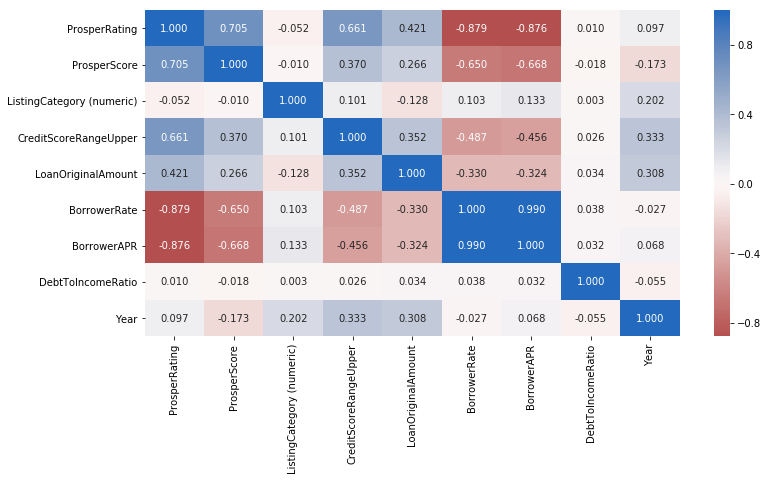

```python
plt.figure(figsize = [12, 6])
sb.heatmap(df2[num_vars].corr(), annot = True, fmt = '.3f',
           cmap = 'vlag_r', center = 0)
plt.show()
```

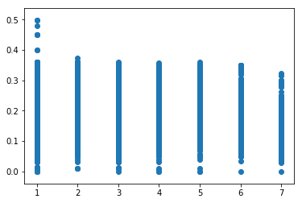

```python
plt.scatter(data = df2, x ='ProsperRating', y = 'BorrowerRate');
```

The scatterplot above does not effectively show the negative correlation between the prosper rating and borrower rate because there are only 7 possible values for the rating and these do not fit into a scatter plot properly

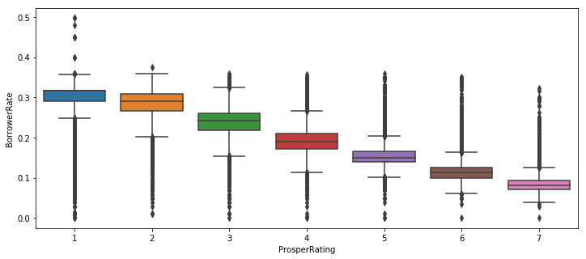

```python
plt.figure(figsize=(12,5));
sb.boxplot(data = df2, x = 'ProsperRating', y = 'BorrowerRate');
plt.xticks();
```

The box plot above provides a better view of the relationship between the prosper rating and borrower rate. We can see that the mean rate values decrease as the prosper rating increases.

Next I am going to look at the number of people in each rating group that are home owners

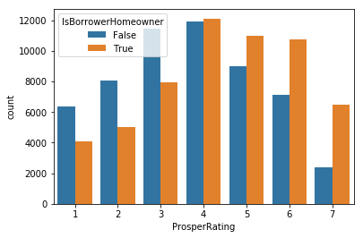

```python
sb.countplot(data = df2, x = 'ProsperRating', hue = 'IsBorrowerHomeowner');
```

From the plot above it can be seen that the number of homeowners increases from the lower prosper rating till a peak at rating number 4 but then starts to decrease from there on. This is possibly because there are a fewer number of people in the dataset with high prosper ratings. The same goes for the number of people who don't own homes. However we can see that from prosper rating 4 and above, the percentage of people that own homes is higher than those who do not compares to the lower ratings where more people do not own homes.

Next I want to create a line plot showing the average borrower rate per year

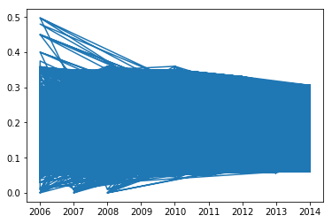

```python
plt.errorbar(data = df2, x = 'Year', y = 'BorrowerRate');
```

The line plot above does not provide useful information, this is because all the points in the dataset are plotted to the line

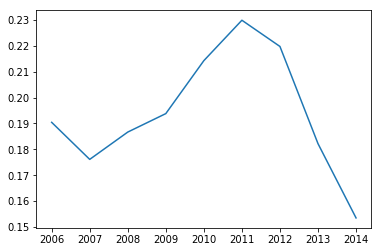

```python
bins_e = np.arange(2005, 2014+1, 1)
bins_c = bins_e[:-1] + 1

year_binned = pd.cut(df2['Year'], bins_e, include_lowest = True)
rate_mean = df2['BorrowerRate'].groupby(year_binned).mean()

plt.errorbar(x = bins_c, y = rate_mean);
```

This is a better plot and we can see that there was a rising theme in the average borrower rate from 2007 till 2011 but the rate has been dropping since then and is at an all time low in 2014

The relationships in the bivariate exploration were somewhat expected. It makes sense that people in higher income ranges will be allowed to borrow larger sums of money and that the lower the propser rating given to an individual the higher their borrower rate would be. Perhaps the most surprising thing was that there was almost no correlation between the debt to income ratio and the borrower rate and APR as I expected there to be one.

## Multivariate Exploration

Here I want to explore the relationship between the income range and the borrower rate for each year in the dataset and also based on if the borrower is a homeowner or not.

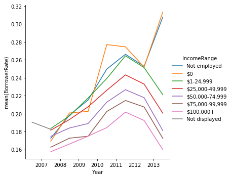

```python
def mean_poly(x, y, bins = 10, **kwargs):
    """ Custom adapted line plot code. """
    # set bin edges if none or int specified
    if type(bins) == int:
        bins = np.linspace(x.min(), x.max(), bins+1)
    bin_centers = (bin_edges[1:] + bin_edges[:-1]) / 2

    # compute counts
    data_bins = pd.cut(x, bins, right = False,
                       include_lowest = True)
    means = y.groupby(data_bins).mean()

    # create plot
    plt.errorbar(x = bin_centers, y = means, **kwargs)

bin_edges = np.arange(2005, 2014+1, 1)
g = sb.FacetGrid(data = df2, hue = 'IncomeRange', height = 5)
g.map(mean_poly, "Year", "BorrowerRate", bins = bin_edges)
g.set_ylabels('mean(BorrowerRate)')
g.add_legend()
```

From the plot above the relationships between the income range and borrower rate follow a very similar trend between the years, but we can also see that the average rates are lower for those in higher income groups than for those in the lower income or not employed groups. Individuals who do not have their income range displayed were from earlier accounts when the company probably did not put people into income ranges

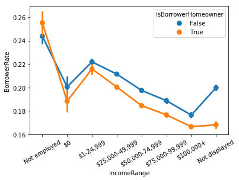

```python
sb.pointplot(data = df2, x = 'IncomeRange', y = 'BorrowerRate', hue = 'IsBorrowerHomeowner');
plt.xticks(rotation=30);
```

Here we can see that borrowers who own homes on average have a lower borrower rate and it follows from the plot above it that higher income ranges have lower borrower rates. Unemplyed individuals have by far the highest borrower rate and an interesting point to view is that individuals in the 1 - 49,999 Dollar income range have higher borrower rates than individuals reported to have an income of 0